# Peer Assessment I

First, let us load the data and necessary packages:

```r
options(warn=-1)
setwd("C:/Home/Courses/Statistics with R")
load("ames_train.Rdata")
library(MASS)
library(dplyr)
library(ggplot2)
```

# 1

Make a labeled histogram (with 30 bins) of the ages of the houses in the data set, and describe the distribution.

```r
# type your code for Question 1 here, and Knit
ames_train_age = ames_train %>% mutate(age = 2017 - Year.Built)
mean(ames_train_age$age)
```

```
## [1] 44.797
```

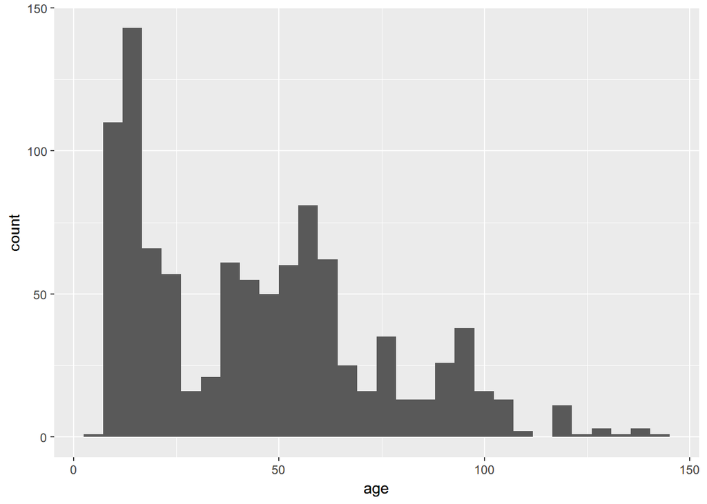

```r
ggplot(ames_train_age, aes(x = age)) + geom_histogram()
```

The distribution is **right-skewed** and **bimodal**, with **a mean of around 45 years**.

# 2

The mantra in real estate is “Location, Location, Location!” Make a graphical display that relates a home price to its neighborhood in Ames, Iowa. Which summary statistics are most appropriate to use for determining the most expensive, least expensive, and most heterogeneous (having the most variation in housing price) neighborhoods? Report which neighborhoods these are based on the summary statistics of your choice. Report the value of your chosen summary statistics for these neighborhoods.

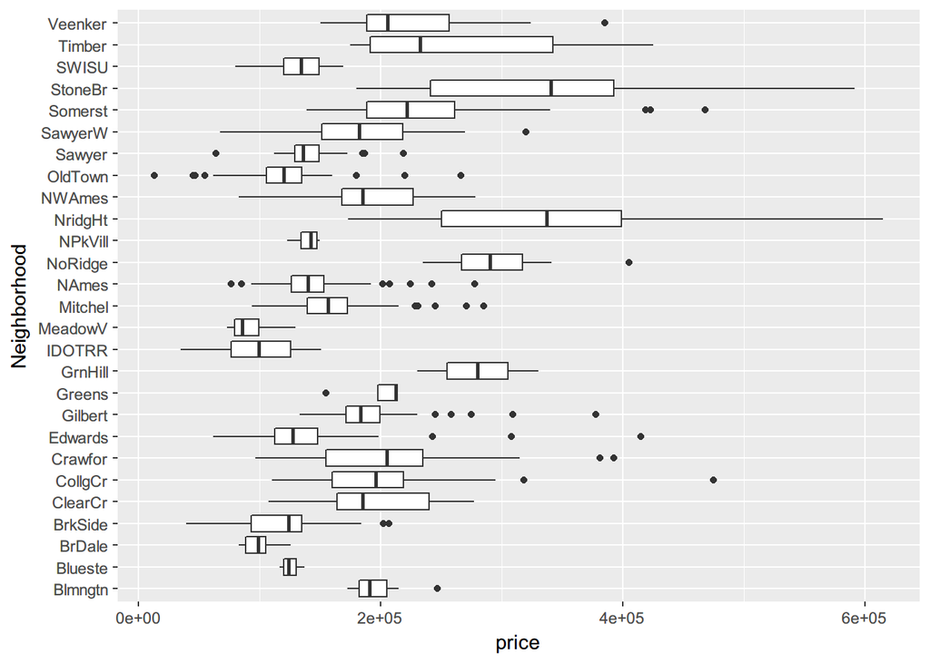

```r
# type your code for Question 2 here, and Knit
aems_train_price_by_neighborhood = ames_train %>% group_by(Neighborhood)
ggplot(aems_train_price_by_neighborhood, aes(x = Neighborhood, y = price)) + geom_boxplot() + coord_flip()
```

```r
aems_train_price_by_neighborhood %>% summarise(mean = mean(price)) %>% arrange(desc(mean)) %>% head(2)
```

```
## # A tibble: 2 × 2
##   Neighborhood     mean
##         <fctr>    <dbl>
## 1      StoneBr 339316.0
## 2      NridgHt 333646.7
```

```r
aems_train_price_by_neighborhood %>% summarise(mean = mean(price)) %>% arrange(mean) %>% head(2)
```

```
## # A tibble: 2 × 2
##   Neighborhood     mean
##         <fctr>    <dbl>
## 1      MeadowV 92946.88
## 2       IDOTRR 97620.69
```

```r
aems_train_price_by_neighborhood %>% summarise(sd = sd(price)) %>% arrange(desc(sd)) %>% head(2)
```

```
## # A tibble: 2 × 2
##   Neighborhood       sd
##         <fctr>    <dbl>
## 1      StoneBr 123459.1
## 2      NridgHt 105088.9
```

The most expensive neighborhood is **StoneBr**.  
The least expensive neighborhood is **MeadowV**.  
The most hetergeneous neighborhood is **StoneBr**.

# 3

Which variable has the largest number of missing values? Explain why it makes sense that there are so many missing values for this variable.

```r
# type your code for Question 3 here, and Knit
sort(colSums(is.na(ames_train)), decreasing=T)[1:2]
```

```
##      Pool.QC Misc.Feature
##          997          971
```

**Pool quality** (`Pool.QC`) has the largest number of missing values. It makes sense because most houses cannot afford the luxury of having a pool.

# 4

We want to predict the natural log of the home prices. Candidate explanatory variables are lot size in square feet (Lot.Area), slope of property (Land.Slope), original construction date (Year.Built), remodel date (Year.Remod.Add), and the number of bedrooms above grade (Bedroom.AbvGr). Pick a model selection or model averaging method covered in the Specialization, and describe how this method works. Then, use this method to find the best multiple regression model for predicting the natural log of the home prices.

```r
# type your code for Question 4 here, and Knit
ames_train_log_price <- ames_train %>% mutate(log_price = log(price))
lm_q4 <- lm(log_price ~ Lot.Area + Land.Slope + Year.Built + Year.Remod.Add + Bedroom.AbvGr, data = ames_train_log_price)
k <- log(nrow(ames_train_log_price))
lm_q4_AIC <- stepAIC(object = lm_q4, direction = 'backward', k = k)
```

```
## Start:  AIC=-2511.42
## log_price ~ Lot.Area + Land.Slope + Year.Built + Year.Remod.Add +
##     Bedroom.AbvGr
##
##                  Df Sum of Sq    RSS     AIC
## <none>                        77.322 -2511.4
## - Land.Slope      2    1.4281 78.750 -2506.9
## - Bedroom.AbvGr   1    5.0628 82.385 -2454.9
## - Lot.Area        1    6.7292 84.051 -2434.9
## - Year.Remod.Add  1   11.9642 89.286 -2374.5
## - Year.Built      1   19.8546 97.177 -2289.8
```

```r
summary(lm_q4_AIC)
```

```
##
## Call:
## lm(formula = log_price ~ Lot.Area + Land.Slope + Year.Built +
##     Year.Remod.Add + Bedroom.AbvGr, data = ames_train_log_price)
##
## Residuals:
##     Min      1Q  Median      3Q     Max
## -2.0878 -0.1651 -0.0211  0.1657  0.9945
##
## Coefficients:
##                  Estimate Std. Error t value Pr(>|t|)
## (Intercept)    -1.371e+01  8.574e-01 -15.996  < 2e-16 ***
## Lot.Area        1.028e-05  1.106e-06   9.296  < 2e-16 ***
## Land.SlopeMod   1.384e-01  4.991e-02   2.773  0.00565 **
## Land.SlopeSev  -4.567e-01  1.514e-01  -3.016  0.00263 **
## Year.Built      6.049e-03  3.788e-04  15.968  < 2e-16 ***
## Year.Remod.Add  6.778e-03  5.468e-04  12.395  < 2e-16 ***
## Bedroom.AbvGr   8.686e-02  1.077e-02   8.063 2.12e-15 ***
## ---
## Signif. codes:  0 '***' 0.001 '**' 0.01 '*' 0.05 '.' 0.1 ' ' 1
##
## Residual standard error: 0.279 on 993 degrees of freedom
## Multiple R-squared:  0.5625, Adjusted R-squared:  0.5598
## F-statistic: 212.8 on 6 and 993 DF,  p-value: < 2.2e-16
```

StepAIC works by removing variables backward one by one based on the calculated AIC (Akaike’s Information Criterion). The result shows that **all the 5 explanatory variables used in the original formula are statistically significant predictors**.

# 5

Which home has the largest squared residual in the previous analysis (Question 4)? Looking at all the variables in the data set, can you explain why this home stands out from the rest (what factors contribute to the high squared residual and why are those factors relevant)?

```r
# type your code for Question 5 here, and Knit
residuals = resid(lm_q4_AIC)
index = which.max(abs(residuals))
index
```

```
## 428
## 428
```

```r
exp(predict(lm_q4_AIC, ames_train[index,]))
```

```
##        1
## 103176.2
```

```r
stack(ames_train[index,])
```

```
##       values             ind
## 1  902207130             PID
## 2        832            area
## 3      12789           price
## 4         30     MS.SubClass
## 5         68    Lot.Frontage
## 6       9656        Lot.Area
## 7          2    Overall.Qual
## 8          2    Overall.Cond
## 9       1923      Year.Built
## 10      1970  Year.Remod.Add
## 11         0    Mas.Vnr.Area
## 12         0    BsmtFin.SF.1
## 13         0    BsmtFin.SF.2
## 14       678     Bsmt.Unf.SF
```

[output cut: 24 more lines]

# 6

Use the same model selection method you chose in Question 4 to again find the best multiple regression model to predict the natural log of home prices, but this time **replacing Lot.Area with log(Lot.Area)**. Do you arrive at a model including the same set of predictors?

```r
# type your code for Question 6 here, and Knit
lm_q6 <- lm(log_price ~ log(Lot.Area) + Land.Slope + Year.Built + Year.Remod.Add + Bedroom.AbvGr, data = ames_train_log_price)
lm_q6_AIC <- stepAIC(object = lm_q6, direction = 'backward', k = k)
```

```
## Start:  AIC=-2615.14
## log_price ~ log(Lot.Area) + Land.Slope + Year.Built + Year.Remod.Add +
##     Bedroom.AbvGr
##
##                  Df Sum of Sq    RSS     AIC
## - Land.Slope      2    0.4429 70.147 -2622.6
## <none>                        69.704 -2615.1
## - Bedroom.AbvGr   1    2.2002 71.904 -2591.0
## - Year.Remod.Add  1   11.8182 81.522 -2465.4
## - log(Lot.Area)   1   14.3474 84.051 -2434.9
## - Year.Built      1   19.4083 89.112 -2376.4
##
## Step:  AIC=-2622.62
## log_price ~ log(Lot.Area) + Year.Built + Year.Remod.Add + Bedroom.AbvGr
##
##                  Df Sum of Sq    RSS     AIC
## <none>                        70.147 -2622.6
## - Bedroom.AbvGr   1    2.0816 72.228 -2600.3
## - Year.Remod.Add  1   11.9455 82.092 -2472.3
## - log(Lot.Area)   1   15.7256 85.872 -2427.3
## - Year.Built      1   19.3032 89.450 -2386.4
```

```r
summary(lm_q6_AIC)
```

```
##
## Call:
## lm(formula = log_price ~ log(Lot.Area) + Year.Built + Year.Remod.Add +
##     Bedroom.AbvGr, data = ames_train_log_price)
##
## Residuals:
##      Min       1Q   Median       3Q      Max
## -2.14609 -0.15825 -0.01477  0.15354  1.01578
##
## Coefficients:
##                  Estimate Std. Error t value Pr(>|t|)
## (Intercept)    -1.557e+01  8.213e-01 -18.964  < 2e-16 ***
## log(Lot.Area)   2.471e-01  1.654e-02  14.935  < 2e-16 ***
## Year.Built      5.964e-03  3.604e-04  16.547  < 2e-16 ***
## Year.Remod.Add  6.765e-03  5.197e-04  13.017  < 2e-16 ***
## Bedroom.AbvGr   5.726e-02  1.054e-02   5.434 6.94e-08 ***
## ---
## Signif. codes:  0 '***' 0.001 '**' 0.01 '*' 0.05 '.' 0.1 ' ' 1
##
## Residual standard error: 0.2655 on 995 degrees of freedom
## Multiple R-squared:  0.6031, Adjusted R-squared:  0.6015
## F-statistic: 377.9 on 4 and 995 DF,  p-value: < 2.2e-16
```

By replacing Lot.Area with log(Lot.Area), the algorithm arrives at a different model, where `Lan.Slope` is excluded and only 4 variables are used.

# 7

Do you think it is better to log transform Lot.Area, in terms of assumptions for linear regression? Make graphs of the predicted values of log home price versus the true values of log home price for the regression models selected for Lot.Area and log(Lot.Area). Referencing these two plots, provide a written support that includes a quantitative justification for your answer in the first part of question 7.

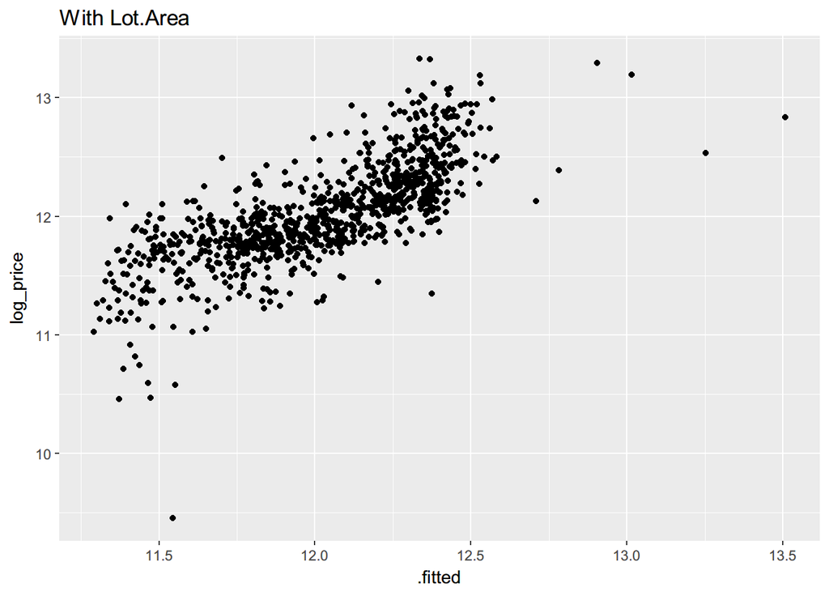

```r
# type your code for Question 7 here, and Knit
ggplot(data = lm_q4_AIC, aes(x = .fitted, y = log_price)) +  geom_point() + ggtitle('With Lot.Area')
```

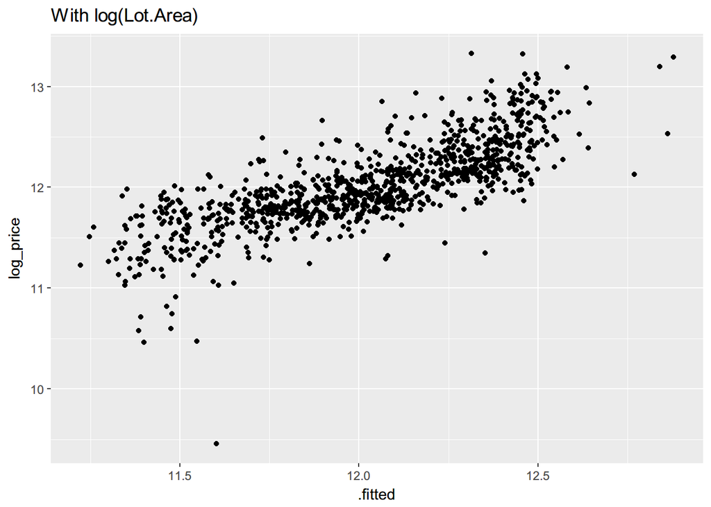

```r
ggplot(data = lm_q6_AIC, aes(x = .fitted, y = log_price)) +  geom_point() + ggtitle('With log(Lot.Area)')
```

I believe it is better to log transform Lot.Area. As we can see from above, after log transforming the data looks more linear. And it’s clear from the model summaries that **log transforming results in a larger R^2 value**.

### 7.0.1